# 1st Project. Write A Data Science Blog Post

## Kyungjin Cho(2021.02.28)

### 1. Business Understanding

Korean Employment platforms 'Job Korea' and 'Albamon' announced on the 6th that the "Satisfactory Level of Salary (46.9%)" ranked first as a result of a survey of 1,288 adult men and women on the "Standards of Job Choice and Maintenance Factors." Other important factors were △ whether they can do what they want (40.8%), △ whether they can do the job they want (39.7%), △ whether they have a growth opportunity for their development (34.6%) △ whether they can move to a better place (22.0%).  
Like the results of the survey, there are many factors to consider when choosing a job such as aptitude, ability, vision and money. If we know the required aptitude and ability for that job, it will be very helpful when we make a decision. Therefore, I'd like to figure out these factors that we need to consider before pursuing prgrammer career.

Base on the available data seeing below, I'd like to figure out answer of following questions.

I. What are the most wanted programming language and framework?  
II. What are the factors that affect career satisfaction?  
III. What are the factors that affect job satisfaction?

### 2. Data Understanding

I analyzed the data after downloading Stackoverflow's 2017 Survey.  
After then, I tried to find the characteristics of respondents.

```python
# Import libraries and read data
import numpy as np
import pandas as pd
import matplotlib.pyplot as plt
import ALookAtTheData as t
from sklearn.linear_model import LinearRegression
from sklearn.model_selection import train_test_split
from sklearn.metrics import r2_score, mean_squared_error
import seaborn as sns
%matplotlib inline

df = pd.read_csv('./survey_results_public.csv')
df.head()
```

|  | Respondent | Professional | ProgramHobby | Country | University | EmploymentStatus | FormalEducation | MajorUndergrad | HomeRemote | CompanySize | ... | StackOverflowMakeMoney | Gender | HighestEducationParents | Race | SurveyLong | QuestionsInteresting | QuestionsConfusing | InterestedAnswers | Salary | ExpectedSalary |
| --- | --- | --- | --- | --- | --- | --- | --- | --- | --- | --- | --- | --- | --- | --- | --- | --- | --- | --- | --- | --- | --- |
| 0 | 1 | Student | Yes, both | United States | No | Not employed, and not looking for work | Secondary school | NaN | NaN | NaN | ... | Strongly disagree | Male | High school | White or of European descent | Strongly disagree | Strongly agree | Disagree | Strongly agree | NaN | NaN |
| 1 | 2 | Student | Yes, both | United Kingdom | Yes, full-time | Employed part-time | Some college/university study without earning ... | Computer science or software engineering | More than half, but not all, the time | 20 to 99 employees | ... | Strongly disagree | Male | A master's degree | White or of European descent | Somewhat agree | Somewhat agree | Disagree | Strongly agree | NaN | 37500.0 |
| 2 | 3 | Professional developer | Yes, both | United Kingdom | No | Employed full-time | Bachelor's degree | Computer science or software engineering | Less than half the time, but at least one day ... | 10,000 or more employees | ... | Disagree | Male | A professional degree | White or of European descent | Somewhat agree | Agree | Disagree | Agree | 113750.0 | NaN |
| 3 | 4 | Professional non-developer who sometimes write... | Yes, both | United States | No | Employed full-time | Doctoral degree | A non-computer-focused engineering discipline | Less than half the time, but at least one day ... | 10,000 or more employees | ... | Disagree | Male | A doctoral degree | White or of European descent | Agree | Agree | Somewhat agree | Strongly agree | NaN | NaN |
| 4 | 5 | Professional developer | Yes, I program as a hobby | Switzerland | No | Employed full-time | Master's degree | Computer science or software engineering | Never | 10 to 19 employees | ... | NaN | NaN | NaN | NaN | NaN | NaN | NaN | NaN | NaN | NaN |

5 rows × 154 columns

```python
# Check the description of data
df.describe()
```

|  | Respondent | CareerSatisfaction | JobSatisfaction | HoursPerWeek | StackOverflowSatisfaction | Salary | ExpectedSalary |
| --- | --- | --- | --- | --- | --- | --- | --- |
| count | 19102.000000 | 16102.000000 | 15253.000000 | 7721.000000 | 13452.000000 | 5009.000000 | 818.000000 |
| mean | 9551.500000 | 7.343932 | 7.000721 | 3.685922 | 8.357865 | 58341.398571 | 32231.521687 |
| std | 5514.416757 | 1.919330 | 2.128648 | 7.330691 | 1.405546 | 40753.384986 | 28543.877274 |
| min | 1.000000 | 0.000000 | 0.000000 | 0.000000 | 0.000000 | 0.000000 | 0.000000 |
| 25% | 4776.250000 | 6.000000 | 6.000000 | 0.000000 | 8.000000 | 27956.989247 | 4716.459735 |
| 50% | 9551.500000 | 8.000000 | 7.000000 | 1.000000 | 8.000000 | 51612.903226 | 29784.946237 |
| 75% | 14326.750000 | 9.000000 | 8.000000 | 3.000000 | 9.000000 | 83333.333333 | 50000.000000 |
| max | 19102.000000 | 10.000000 | 10.000000 | 40.000000 | 10.000000 | 195000.000000 | 120000.000000 |

```python
# Check the number of rows and columns
df.shape
```

```
(19102, 154)
```

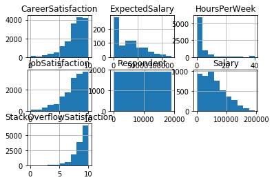

```python
# Check hist of data
df.hist();
```

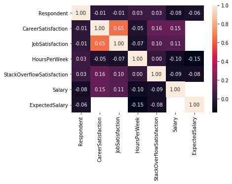

```python
# Check heatmap(relationship) of data
sns.heatmap(df.corr(), annot=True, fmt='.2f')
```

▷ Job satisfaction and career satisfaction are highly correlated.  
▷ Career satisfaction has somewhat correlation with salary and stackoverflow satisfaction  
▷ Job satisfaction has somewhat correlation with salary and stackoverflow satisfaction

```python
# Check the number of missing values
df.isnull().sum()
```

```
Respondent                         0
Professional                       0
ProgramHobby                       0
Country                            0
University                         0
EmploymentStatus                   0
FormalEducation                    0
MajorUndergrad                  3203
HomeRemote                      2631
CompanySize                     4449
CompanyType                     4493
YearsProgram                      97
YearsCodedJob                   3711
YearsCodedJobPast              18753
DeveloperType                   5330
WebDeveloperType               14816
MobileDeveloperType            18546
NonDeveloperType               17414
CareerSatisfaction              3000
JobSatisfaction                 3849
ExCoderReturn                  18767
ExCoderNotForMe                18770
ExCoderBalance                 18767
ExCoder10Years                 18766
ExCoderBelonged                18767
ExCoderSkills                  18766
ExCoderWillNotCode             18770
ExCoderActive                  18767
PronounceGIF                     162
ProblemSolving                  6882
                               ...
InfluenceRecruitment           10858
InfluenceCommunication         10852
StackOverflowDescribes          5546
StackOverflowSatisfaction       5650
StackOverflowDevices            6156
StackOverflowFoundAnswer        6411
StackOverflowCopiedCode         6525
StackOverflowJobListing         6677
StackOverflowCompanyPage        6691
StackOverflowJobSearch          6695
StackOverflowNewQuestion        6630
StackOverflowAnswer             6657
StackOverflowMetaChat           6688
StackOverflowAdsRelevant        7575
StackOverflowAdsDistracting     7261
StackOverflowModeration         7766
StackOverflowCommunity          7038
StackOverflowHelpful            6560
StackOverflowBetter             6640
StackOverflowWhatDo             6717
StackOverflowMakeMoney          7434
Gender                          6192
HighestEducationParents         6249
Race                            6884
SurveyLong                      6299
QuestionsInteresting            6366
QuestionsConfusing              6396
InterestedAnswers               6342
Salary                         14093
ExpectedSalary                 18284
Length: 154, dtype: int64
```

```python
# Check the proportion of missing values
df.isnull().sum() / len(df)
```

```
Respondent                     0.000000
Professional                   0.000000
ProgramHobby                   0.000000
Country                        0.000000
University                     0.000000
EmploymentStatus               0.000000
FormalEducation                0.000000
MajorUndergrad                 0.167679
HomeRemote                     0.137734
CompanySize                    0.232908
CompanyType                    0.235211
YearsProgram                   0.005078
YearsCodedJob                  0.194273
YearsCodedJobPast              0.981730
DeveloperType                  0.279028
WebDeveloperType               0.775626
MobileDeveloperType            0.970893
NonDeveloperType               0.911632
CareerSatisfaction             0.157052
JobSatisfaction                0.201497
ExCoderReturn                  0.982463
ExCoderNotForMe                0.982620
ExCoderBalance                 0.982463
ExCoder10Years                 0.982410
ExCoderBelonged                0.982463
ExCoderSkills                  0.982410
ExCoderWillNotCode             0.982620
ExCoderActive                  0.982463
PronounceGIF                   0.008481
ProblemSolving                 0.360276
                                 ...
InfluenceRecruitment           0.568422
InfluenceCommunication         0.568108
StackOverflowDescribes         0.290336
StackOverflowSatisfaction      0.295781
StackOverflowDevices           0.322270
StackOverflowFoundAnswer       0.335619
StackOverflowCopiedCode        0.341587
StackOverflowJobListing        0.349545
StackOverflowCompanyPage       0.350277
StackOverflowJobSearch         0.350487
StackOverflowNewQuestion       0.347084
StackOverflowAnswer            0.348498
StackOverflowMetaChat          0.350120
StackOverflowAdsRelevant       0.396555
StackOverflowAdsDistracting    0.380117
StackOverflowModeration        0.406554
StackOverflowCommunity         0.368443
StackOverflowHelpful           0.343420
StackOverflowBetter            0.347608
StackOverflowWhatDo            0.351639
StackOverflowMakeMoney         0.389174
Gender                         0.324155
HighestEducationParents        0.327139
Race                           0.360381
SurveyLong                     0.329756
QuestionsInteresting           0.333264
QuestionsConfusing             0.334834
InterestedAnswers              0.332007
Salary                         0.737776
ExpectedSalary                 0.957177
Length: 154, dtype: float64
```

```python
no_nulls = set(df.columns[df.isnull().mean()==0])#Provide a set of columns with 0 missing values.

t.no_null_cols(no_nulls)
```

```
Nice job that looks right!
```

```
'<img src="https://bit.ly/2K9X0gD">'
```

```python
most_missing_cols = set(df.columns[df.isnull().mean() > 0.75])#Provide a set of columns with more than 75% of the values missing

t.most_missing_cols(most_missing_cols)
```

```
Nice job that looks right!
```

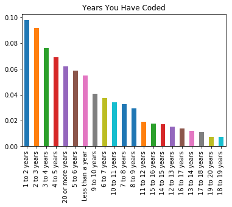

```python
years_vals = df.YearsCodedJob.value_counts()#Provide a pandas series of yeard coded job (job experience)

# The below should be a bar chart of the proportion of individuals in each professional category if your years_coded job
# is set up correctly.

(years_vals/df.shape[0]).plot(kind="bar");
plt.title("Years You Have Coded");
```

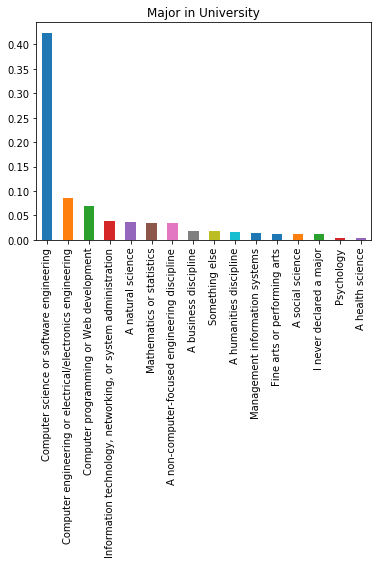

```python
major_vals = df.MajorUndergrad.value_counts()#Provide a pandas series of major(Undergraduate)

# The below should be a bar chart of the proportion of individuals in each professional category if your major of undergraduate
# is set up correctly.

(major_vals/df.shape[0]).plot(kind="bar");
plt.title("Major in University");
```

▷ Most of respondents graduated from university or college with a degree in computer science or computer engineering.

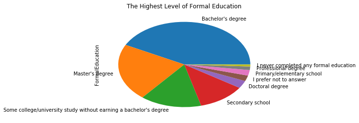

```python
education_vals = df.FormalEducation.value_counts()#Provide a pandas series of education level

# The below should be a bar chart of the proportion of individuals in each professional category if education level data
# is set up correctly.

(education_vals/df.shape[0]).plot(kind="pie");
plt.title("The Highest Level of Formal Education");
```

▷ Most of respondents have bachelor's degree or Master's degree.

```
Text(0.5,1,'Company Size')
```

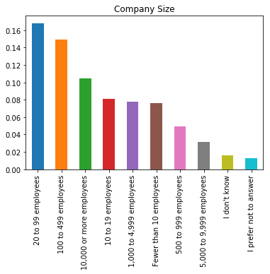

```python
# Create a bar chart about company size status
size_vals = df.CompanySize.value_counts()
(size_vals/df.shape[0]).plot(kind="bar");
plt.title("Company Size")
```

▷ Most of respondents have less than 500 employees.

```python
pd.DataFrame(df.query("CompanySize == '10,000 or more employees' and (SeriousWork == 'Agree' or SeriousWork == 'Disagree')").groupby(['SeriousWork', 'YearsCodedJob']).mean()['JobSatisfaction'])
```

| SeriousWork | YearsCodedJob | JobSatisfaction |
| --- | --- | --- |
| Agree | 1 to 2 years | 6.526316 |
|  | 10 to 11 years | 7.259259 |
|  | 11 to 12 years | 6.785714 |
|  | 12 to 13 years | 7.357143 |
|  | 13 to 14 years | 6.076923 |
|  | 14 to 15 years | 7.166667 |
|  | 15 to 16 years | 7.526316 |
|  | 16 to 17 years | 6.875000 |
|  | 17 to 18 years | 6.636364 |
|  | 18 to 19 years | 6.636364 |
|  | 19 to 20 years | 7.200000 |
|  | 2 to 3 years | 6.903226 |
|  | 20 or more years | 6.836364 |
|  | 3 to 4 years | 6.840909 |
|  | 4 to 5 years | 7.024390 |
|  | 5 to 6 years | 6.236842 |
|  | 6 to 7 years | 7.458333 |
|  | 7 to 8 years | 6.708333 |
|  | 8 to 9 years | 6.857143 |
|  | 9 to 10 years | 7.000000 |
|  | Less than a year | 6.921053 |
| Disagree | 1 to 2 years | 5.000000 |
|  | 14 to 15 years | 5.000000 |
|  | 15 to 16 years | 5.333333 |
|  | 2 to 3 years | 7.000000 |
|  | 20 or more years | 7.000000 |
|  | 3 to 4 years | 3.000000 |
|  | 4 to 5 years | 7.000000 |
|  | 5 to 6 years | 6.000000 |
|  | 6 to 7 years | 4.000000 |
|  | 8 to 9 years | 7.000000 |
|  | 9 to 10 years | 5.250000 |
|  | Less than a year | 6.500000 |

▷ Employees who take their work seriously have higher job satisfaction.

### 3. Data Preparation

The data was not clean for analysis because of missing data and complicated answers.  
I deleted missing data and classified complicated data before data analysis.  
I figured out necessary categories for data analysis, and deleted missing data.  
Also, I decided to clean the data that includes complicated responses when I analyze it for efficiency. I wanted to analyze two kinds of subjects, and both categories involved complicated data.

```python
# Check the number of missing values
df.isnull().sum()
```

```
Respondent                         0
Professional                       0
ProgramHobby                       0
Country                            0
University                         0
EmploymentStatus                   0
FormalEducation                    0
MajorUndergrad                  3203
HomeRemote                      2631
CompanySize                     4449
CompanyType                     4493
YearsProgram                      97
YearsCodedJob                   3711
YearsCodedJobPast              18753
DeveloperType                   5330
WebDeveloperType               14816
MobileDeveloperType            18546
NonDeveloperType               17414
CareerSatisfaction              3000
JobSatisfaction                 3849
ExCoderReturn                  18767
ExCoderNotForMe                18770
ExCoderBalance                 18767
ExCoder10Years                 18766
ExCoderBelonged                18767
ExCoderSkills                  18766
ExCoderWillNotCode             18770
ExCoderActive                  18767
PronounceGIF                     162
ProblemSolving                  6882
                               ...
InfluenceRecruitment           10858
InfluenceCommunication         10852
StackOverflowDescribes          5546
StackOverflowSatisfaction       5650
StackOverflowDevices            6156
StackOverflowFoundAnswer        6411
StackOverflowCopiedCode         6525
StackOverflowJobListing         6677
StackOverflowCompanyPage        6691
StackOverflowJobSearch          6695
StackOverflowNewQuestion        6630
StackOverflowAnswer             6657
StackOverflowMetaChat           6688
StackOverflowAdsRelevant        7575
StackOverflowAdsDistracting     7261
StackOverflowModeration         7766
StackOverflowCommunity          7038
StackOverflowHelpful            6560
StackOverflowBetter             6640
StackOverflowWhatDo             6717
StackOverflowMakeMoney          7434
Gender                          6192
HighestEducationParents         6249
Race                            6884
SurveyLong                      6299
QuestionsInteresting            6366
QuestionsConfusing              6396
InterestedAnswers               6342
Salary                         14093
ExpectedSalary                 18284
Length: 154, dtype: int64
```

```python
#Subset to only quantitative vars
num_vars = df[['Salary', 'CareerSatisfaction', 'HoursPerWeek', 'JobSatisfaction', 'StackOverflowSatisfaction']]


num_vars.head()
```

|  | Salary | CareerSatisfaction | HoursPerWeek | JobSatisfaction | StackOverflowSatisfaction |
| --- | --- | --- | --- | --- | --- |
| 0 | NaN | NaN | 0.0 | NaN | 9.0 |
| 1 | NaN | NaN | NaN | NaN | 8.0 |
| 2 | 113750.0 | 8.0 | NaN | 9.0 | 8.0 |
| 3 | NaN | 6.0 | 5.0 | 3.0 | 10.0 |
| 4 | NaN | 6.0 | NaN | 8.0 | NaN |

```python
drop_job_df = num_vars.dropna(subset=['JobSatisfaction'], axis=0) #Drop the rows with missing salaries

# test look
drop_job_df.head()
```

|  | Salary | CareerSatisfaction | HoursPerWeek | JobSatisfaction | StackOverflowSatisfaction |
| --- | --- | --- | --- | --- | --- |
| 2 | 113750.0 | 8.0 | NaN | 9.0 | 8.0 |
| 3 | NaN | 6.0 | 5.0 | 3.0 | 10.0 |
| 4 | NaN | 6.0 | NaN | 8.0 | NaN |
| 6 | NaN | 7.0 | 1.0 | 6.0 | 8.0 |
| 7 | NaN | 7.0 | 1.0 | 7.0 | 7.0 |

```python
fill_mean = lambda col: col.fillna(col.mean()) # Mean function

fill_df = drop_job_df.apply(fill_mean, axis=0) #Fill all missing values with the mean of the column.

# test look
fill_df.head()
```

|  | Salary | CareerSatisfaction | HoursPerWeek | JobSatisfaction | StackOverflowSatisfaction |
| --- | --- | --- | --- | --- | --- |
| 2 | 113750.000000 | 8.0 | 3.331964 | 9.0 | 8.000000 |
| 3 | 58266.522402 | 6.0 | 5.000000 | 3.0 | 10.000000 |
| 4 | 58266.522402 | 6.0 | 3.331964 | 8.0 | 8.385003 |
| 6 | 58266.522402 | 7.0 | 1.000000 | 6.0 | 8.000000 |
| 7 | 58266.522402 | 7.0 | 1.000000 | 7.0 | 7.000000 |

### 4. Data Modeling

Regression analysis was used for data analysis although there are diverse modeling techniques. According to Wikipedia, regression analysis is a set of statistical process for estimating the relationships between a dependent variable and one or more independent variables.

I decided to utilize regression analysis for this data becuase of the below reason.

Fist of all, this data had lots of variables. I wanted to figure out relationships between the independent and dependent variables after analyzing related variables with each other. I forecasted that relationships between existing variables has a interpretation after exploring the data by plotting it on a graph. Also, responses were composed of numerical values and texts. Therefore, there was limitation to utilize diverse techniques because of this fixed dataset.

```python
# Import data and libraries
import HowToBreakIntoTheField as t
schema = pd.read_csv('./survey_results_schema.csv')
schema.head()
```

|  | Column | Question |
| --- | --- | --- |
| 0 | Respondent | Respondent ID number |
| 1 | Professional | Which of the following best describes you? |
| 2 | ProgramHobby | Do you program as a hobby or contribute to ope... |
| 3 | Country | In which country do you currently live? |
| 4 | University | Are you currently enrolled in a formal, degree... |

```python
def get_description(column_name, schema=schema):
    '''
    INPUT - schema - pandas dataframe with the schema of the developers survey
            column_name - string - the name of the column you would like to know about
    OUTPUT -
            desc - string - the description of the column
    '''
    desc = list(schema[schema['Column'] == column_name]['Question'])[0]
    return desc

#test your code
#Check your function against solution - you shouldn't need to change any of the below code
get_description(df.columns[0]) # This should return a string of the first column description
```

```
'Respondent ID number'
```

```python
#Check your function against solution - you shouldn't need to change any of the below code
descrips = set(get_description(col) for col in df.columns)
t.check_description(descrips)
```

```
Nice job it looks like your function works correctly!
```

```python
# Get description of question
get_description('WantWorkLanguage')
```

```
'Which of the following languages have you done extensive development work in over the past year, and which do you want to work in over the next year?'
```

```python
work_language_vals = df.WantWorkLanguage.value_counts()#Provide a pandas series of the counts for each WantWorkLanguage status

work_language_vals # assure this looks right
```

```
JavaScript                                                                    233
Python                                                                        206
Java                                                                          190
C#; JavaScript; SQL                                                           169
C#                                                                            164
C#; JavaScript; SQL; TypeScript                                               150
Java; JavaScript                                                              134
C++                                                                           122
Swift                                                                         112
JavaScript; Python                                                            111
C#; SQL                                                                       107
JavaScript; PHP; SQL                                                          104
C#; JavaScript; TypeScript                                                    101
Go                                                                             91
C#; JavaScript                                                                 86
C++; Python                                                                    86
JavaScript; TypeScript                                                         79
Java; JavaScript; SQL                                                          79
Scala                                                                          72
JavaScript; PHP                                                                69
Java; Python                                                                   62
Smalltalk                                                                      56
Java; JavaScript; Python                                                       55
Go; Python                                                                     54
Ruby                                                                           53
TypeScript                                                                     52
C++; C#                                                                        51
C; C++                                                                         49
Java; SQL                                                                      45
C#; F#; JavaScript; SQL; TypeScript                                            44
                                                                             ...
C++; Haskell; JavaScript                                                        1
C; C++; Matlab; Objective-C; Python; Ruby; Swift                                1
Assembly; Clojure; Elixir; F#                                                   1
C; C++; JavaScript; Python; Swift                                               1
C#; F#; Groovy; JavaScript; TypeScript                                          1
C++; F#; Java; Objective-C; TypeScript                                          1
C; C++; C#; Java; Rust                                                          1
Clojure; Erlang; Groovy; JavaScript; Python; SQL                                1
C++; Elixir; Objective-C; Swift                                                 1
C++; C#; JavaScript; Python; TypeScript                                         1
C; C++; C#; Clojure; Erlang; JavaScript; Matlab; Python; Scala; TypeScript      1
C; C#; Clojure; Erlang; Haskell; Java; JavaScript; Python; SQL                  1
C++; C#; F#; Haskell; R; TypeScript                                             1
C#; JavaScript; Python; SQL; TypeScript; VB.NET; VBA                            1
Elixir; Python; Rust; Swift                                                     1
CoffeeScript; R; Ruby; Scala; TypeScript                                        1
Groovy; Java; Python; TypeScript                                                1
Assembly; C; Python; Rust; Scala                                                1
Assembly; C++; R                                                                1
Elixir; Go; JavaScript; Swift                                                   1
C; C++; C#; Rust; Swift                                                         1
C; C++; Julia; Perl; R; Swift                                                   1
CoffeeScript; Java; JavaScript; Lua; PHP; Python; Swift                         1
Haskell; JavaScript; Python; SQL                                                1
C#; Elixir; JavaScript; Rust; SQL                                               1
C; Perl                                                                         1
C#; CoffeeScript; JavaScript; Python; SQL                                       1
JavaScript; PHP; Smalltalk; SQL                                                 1
Groovy; Java; JavaScript; PHP; Python; Ruby; SQL                                1
CoffeeScript; Go; Haskell; TypeScript                                           1
Name: WantWorkLanguage, Length: 5059, dtype: int64
```

[figure not shown]

```python
# The below should be a bar chart of the proportion of language what you want
# if it is set up correctly.

(work_language_vals/df.shape[0]).plot(kind="bar");
plt.title("Programming Language You Want");
```

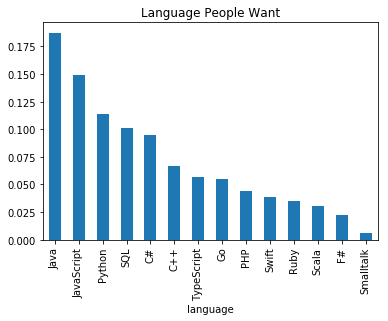

```python
# Set the possible values and make a graph
possible_vals = ["JavaScript", "Python", "Java", "C#", "SQL", "C++",
                 "TypeScript", "Swift", "PHP", "Go", "Scala", "Smalltalk",
                 "Ruby", "F#", "Other"]

def clean_and_plot(df, title='Language People Want', plot=True):
    '''
    INPUT
        df - a dataframe holding the WantWorkLanguage column
        title - string the title of your plot
        axis - axis object
        plot - bool providing whether or not you want a plot back

    OUTPUT
        study_df - a dataframe with the count of how many individuals
        Displays a plot of pretty things related to the WantWorkLanguage column.
    '''
    language = df['WantWorkLanguage'].value_counts().reset_index()
    language.rename(columns={'index': 'language', 'WantWorkLanguage': 'count'}, inplace=True)
    language_df = t.total_count(language, 'language', 'count', possible_vals)

    language_df.set_index('language', inplace=True)
    if plot:
        (language_df/language_df.sum()).plot(kind='bar', legend=None);
        plt.title(title);
        plt.show()
    props_language_df = language_df/language_df.sum()
    return props_language_df

props_df = clean_and_plot(df)
```

▷ Most popular languages are Java, JavaScript, Python, SQL and C#.

```python
# Get description of question
get_description('WantWorkFramework')
```

```
'Which of the following libraries, frameworks, and tools have you done extensive development work in over the past year, and which do you want to work in over the next year?'
```

```python
work_frame_vals = df.WantWorkFramework.value_counts()#Provide a pandas series of the counts for each WantWorkFramework

work_frame_vals # assure this looks right
```

```
.NET Core                                                            798
Node.js                                                              546
Node.js; React                                                       535
React                                                                496
AngularJS; Node.js                                                   451
AngularJS; Node.js; React                                            413
AngularJS                                                            396
Xamarin; .NET Core                                                   280
AngularJS; .NET Core                                                 215
Spark                                                                196
AngularJS; Node.js; .NET Core                                        172
Hadoop; Spark                                                        164
Hadoop                                                               149
AngularJS; React                                                     148
Firebase                                                             139
Node.js; .NET Core                                                   139
Xamarin                                                              123
Node.js; React; .NET Core                                            121
AngularJS; Xamarin; .NET Core                                        113
React; .NET Core                                                     112
AngularJS; Node.js; React; .NET Core                                 103
AngularJS; Node.js; React; Firebase                                   97
AngularJS; Node.js; Xamarin; .NET Core                                96
Node.js; React; Firebase                                              81
AngularJS; Node.js; React; Xamarin; .NET Core                         74
AngularJS; Node.js; React; Cordova                                    69
AngularJS; Node.js; Cordova                                           56
AngularJS; React; .NET Core                                           53
AngularJS; Hadoop; Node.js                                            52
React; Firebase                                                       51
                                                                    ...
AngularJS; Node.js; React; Spark; Cordova; Xamarin                     1
AngularJS; Hadoop; Node.js; Spark; Firebase; .NET Core                 1
AngularJS; React; Cordova; Xamarin; Firebase; .NET Core                1
Hadoop; React; Spark; Firebase; .NET Core                              1
AngularJS; Spark; Cordova; .NET Core                                   1
Node.js; React; Spark; Cordova                                         1
Hadoop; Cordova; Firebase; .NET Core                                   1
Node.js; Spark; Cordova; Xamarin; Firebase; .NET Core                  1
AngularJS; Node.js; Spark; Cordova                                     1
React; Spark; Xamarin; .NET Core                                       1
Hadoop; Cordova; .NET Core                                             1
Hadoop; React; Cordova; Firebase; .NET Core                            1
AngularJS; Hadoop; Cordova; Xamarin; Firebase                          1
Hadoop; Node.js; Cordova                                               1
AngularJS; Node.js; React; Spark; Xamarin; .NET Core                   1
Hadoop; Firebase; .NET Core                                            1
AngularJS; Hadoop; Node.js; React; Xamarin                             1
Hadoop; Node.js; React; Cordova; Xamarin; .NET Core                    1
Hadoop; Node.js; React; Spark; Xamarin; Firebase; .NET Core            1
React; Spark; Cordova; Firebase                                        1
AngularJS; Hadoop; Node.js; Spark; Cordova; .NET Core                  1
AngularJS; Hadoop; Node.js; Cordova; Xamarin; Firebase; .NET Core      1
Hadoop; Node.js; React; Xamarin; Firebase                              1
Hadoop; Spark; Firebase; .NET Core                                     1
AngularJS; Hadoop; Node.js; React; Spark; Firebase; .NET Core          1
AngularJS; Hadoop; Node.js; Cordova; Firebase; .NET Core               1
Hadoop; React; Firebase                                                1
Node.js; React; Spark; Cordova; Xamarin; .NET Core                     1
React; Cordova; .NET Core                                              1
AngularJS; React; Spark; Firebase                                      1
Name: WantWorkFramework, Length: 322, dtype: int64
```

[figure not shown]

```python
# The below should be a bar chart of the proportion of framework what you want
# if it is set up correctly.

(work_frame_vals/df.shape[0]).plot(kind="bar");
plt.title("Programming Framework You Want");
```

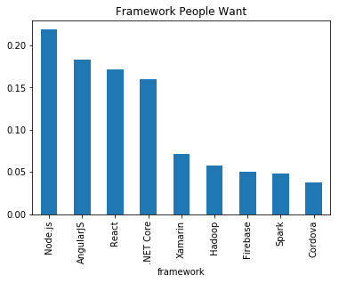

```python
# Set the possible values and make a graph
possible_vals = [".NET Core", "Node.js", "React", "AngularJS", "Xamarin", "Spark",
                 "Hadoop", "Firebase", "Cordova", "Other"]

def clean_and_plot(df, title='Framework People Want', plot=True):
    '''
    INPUT
        df - a dataframe holding the WantWorkFramework column
        title - string the title of your plot
        axis - axis object
        plot - bool providing whether or not you want a plot back

    OUTPUT
        study_df - a dataframe with the count of how many individuals
        Displays a plot of pretty things related to the WantWorkFramework column.
    '''
    frame = df['WantWorkFramework'].value_counts().reset_index()
    frame.rename(columns={'index': 'framework', 'WantWorkFramework': 'count'}, inplace=True)
    frame_df = t.total_count(frame, 'framework', 'count', possible_vals)

    frame_df.set_index('framework', inplace=True)
    if plot:
        (frame_df/frame_df.sum()).plot(kind='bar', legend=None);
        plt.title(title);
        plt.show()
    props_frame_df = frame_df/frame_df.sum()
    return props_frame_df

props_df = clean_and_plot(df)
```

▷ Most popular frameworks are Node.js, AngularJS, React, NET Core and Xamarin.

# 3. Career Satisfaction

```python
df['CareerSatisfaction'].isnull().mean() # missing values
```

```
0.15705161763166162
```

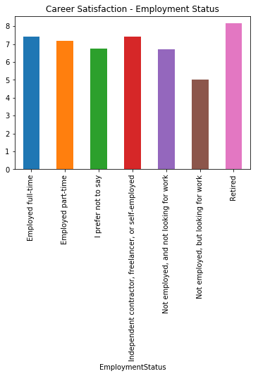

```python
(df.groupby(['EmploymentStatus']).mean()['CareerSatisfaction']).plot(kind="bar");
plt.title("Career Satisfaction - Employment Status");
```

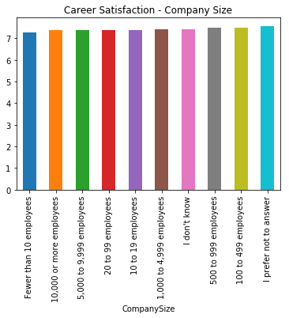

```python
(df.groupby(['CompanySize']).mean()['CareerSatisfaction'].sort_values()).plot(kind="bar");
plt.title("Career Satisfaction - Company Size");
```

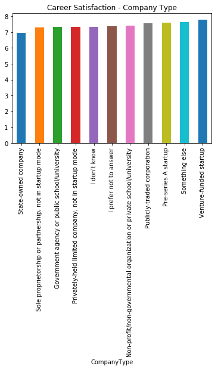

```python
(df.groupby(['CompanyType']).mean()['CareerSatisfaction'].sort_values()).plot(kind="bar");
plt.title("Career Satisfaction - Company Type");
```

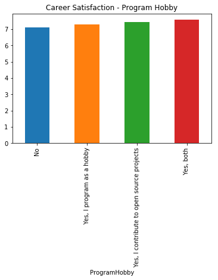

```python
(df.groupby(['ProgramHobby']).mean()['CareerSatisfaction'].sort_values().dropna()).plot(kind="bar");
plt.title("Career Satisfaction - Program Hobby");
```

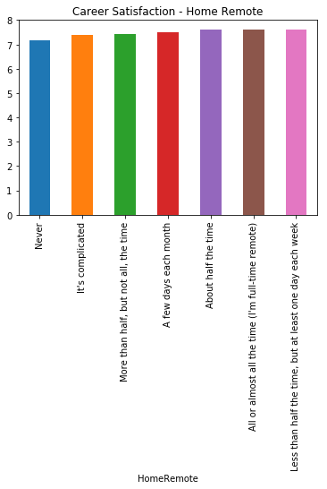

```python
(df.groupby(['HomeRemote']).mean()['CareerSatisfaction'].sort_values().dropna()).plot(kind="bar");
plt.title("Career Satisfaction - Home Remote");
```

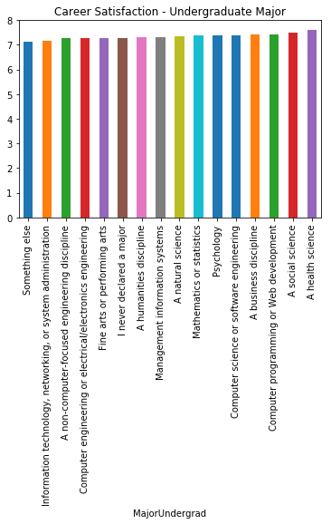

```python
(df.groupby(['MajorUndergrad']).mean()['CareerSatisfaction'].sort_values().dropna()).plot(kind="bar");
plt.title("Career Satisfaction - Undergraduate Major");
```

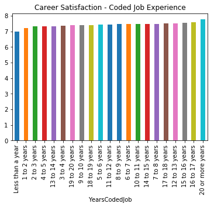

```python
(df.groupby(['YearsCodedJob']).mean()['CareerSatisfaction'].sort_values().dropna()).plot(kind="bar");
plt.title("Career Satisfaction - Coded Job Experience");
```

```python
import numpy as np
import pandas as pd
import matplotlib.pyplot as plt
from sklearn.linear_model import LinearRegression
from sklearn.model_selection import train_test_split
from sklearn.metrics import r2_score, mean_squared_error
import seaborn as sns
import RemovingData as t
%matplotlib inline
```

```python
prop_jobs = 1 - df.isnull()['JobSatisfaction'].mean()# Proportion of individuals in the dataset with job satisfaction reported

prop_jobs
```

```
0.79850277457857821
```

```python
job_rm = num_vars.dropna(subset=['JobSatisfaction'], axis=0)# dataframe with rows for nan Job Satisfaction removed

job_rm.head()
```

|  | Salary | CareerSatisfaction | HoursPerWeek | JobSatisfaction | StackOverflowSatisfaction |
| --- | --- | --- | --- | --- | --- |
| 2 | 113750.0 | 8.0 | NaN | 9.0 | 8.0 |
| 3 | NaN | 6.0 | 5.0 | 3.0 | 10.0 |
| 4 | NaN | 6.0 | NaN | 8.0 | NaN |
| 6 | NaN | 7.0 | 1.0 | 6.0 | 8.0 |
| 7 | NaN | 7.0 | 1.0 | 7.0 | 7.0 |

```python
X = df[['CareerSatisfaction', 'Salary', 'HoursPerWeek', 'StackOverflowSatisfaction']]
y = df['JobSatisfaction']

# Split data into training and test data, and fit a linear model
X_train, X_test, y_train, y_test = train_test_split(X, y , test_size=.30, random_state=42)
lm_model = LinearRegression(normalize=True)

# If our model works, it should just fit our model to the data. Otherwise, it will let us know.
try:
    lm_model.fit(X_train, y_train)
except:
    print("Oh no! It doesn't work!!!")
```

```
Oh no! It doesn't work!!!
```

```python
all_rm = num_vars.dropna(axis=0) # dataframe with rows for nan Job Satisfaction removed

all_rm.head()
```

|  | Salary | CareerSatisfaction | HoursPerWeek | JobSatisfaction | StackOverflowSatisfaction |
| --- | --- | --- | --- | --- | --- |
| 25 | 175000.000000 | 7.0 | 0.0 | 7.0 | 9.0 |
| 34 | 14838.709677 | 10.0 | 1.0 | 8.0 | 10.0 |
| 52 | 15674.203822 | 6.0 | 4.0 | 5.0 | 8.0 |
| 57 | 43010.752688 | 10.0 | 2.0 | 6.0 | 10.0 |
| 70 | 65000.000000 | 8.0 | 2.0 | 5.0 | 7.0 |

```python
X_2 = all_rm[['CareerSatisfaction', 'HoursPerWeek', 'Salary', 'StackOverflowSatisfaction']]
y_2 = all_rm['JobSatisfaction']

# Split data into training and test data, and fit a linear model
X_2_train, X_2_test, y_2_train, y_2_test = train_test_split(X_2, y_2 , test_size=.30, random_state=42)
lm_2_model = LinearRegression(normalize=True)

# If our model works, it should just fit our model to the data. Otherwise, it will let us know.
try:
    lm_2_model.fit(X_2_train, y_2_train)
except:
    print("Oh no! It doesn't work!!!")
```

```python
y_test_preds = lm_2_model.predict(X_2_test)# Predictions here
r2_test = r2_score(y_2_test, y_test_preds) # Rsquared here

"The r-squared score for your model was {} on {} values.".format(r2_score(y_2_test, y_test_preds), len(y_2_test))
```

```
'The r-squared score for your model was 0.35376007667077936 on 645 values.'
```

```python
#Split into explanatory and response variables
X = fill_df[['CareerSatisfaction', 'HoursPerWeek', 'Salary', 'StackOverflowSatisfaction']]
y = fill_df['JobSatisfaction']

#Split into train and test
X_train, X_test, y_train, y_test = train_test_split(X, y, test_size = .30, random_state=42)

lm_model = LinearRegression(normalize=True) # Instantiate
lm_model.fit(X_train, y_train) #Fit

#Predict and score the model
y_test_preds = lm_model.predict(X_test)

#Rsquared and y_test
rsquared_score = r2_score(y_test, y_test_preds)
length_y_test = len(y_test)

"The r-squared score for your model was {} on {} values.".format(rsquared_score, length_y_test)
```

```
'The r-squared score for your model was 0.4382923523069 on 4576 values.'
```

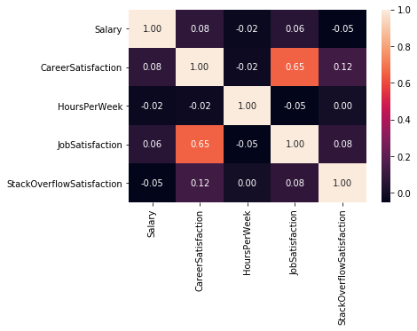

```python
# Check heatmap(relationship) of data
sns.heatmap(fill_df.corr(), annot=True, fmt='.2f')
```

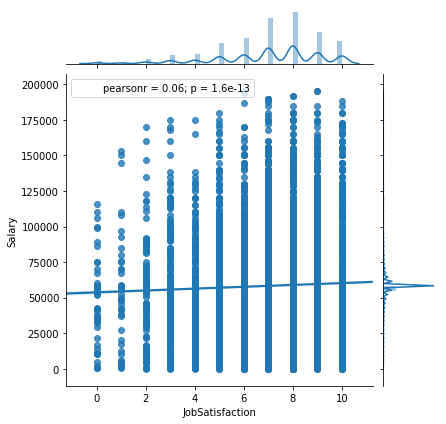

```python
sns.jointplot(x=fill_df["JobSatisfaction"], y=fill_df["Salary"], kind='reg')
```

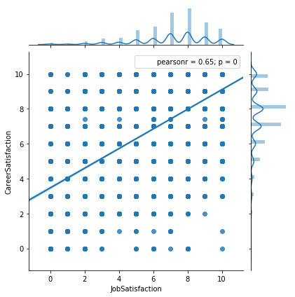

```python
sns.jointplot(x=fill_df["JobSatisfaction"], y=fill_df["CareerSatisfaction"], kind='reg')
```

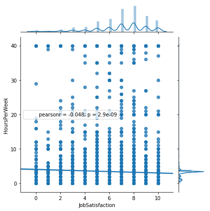

```python
sns.jointplot(x=fill_df["JobSatisfaction"], y=fill_df["HoursPerWeek"], kind='reg')
```

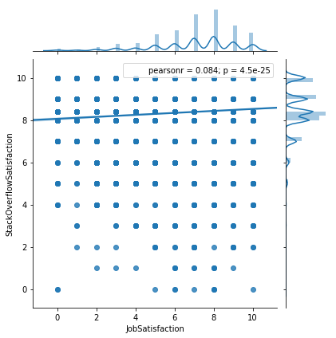

```python
sns.jointplot(x=fill_df["JobSatisfaction"], y=fill_df['StackOverflowSatisfaction'], kind='reg')
```

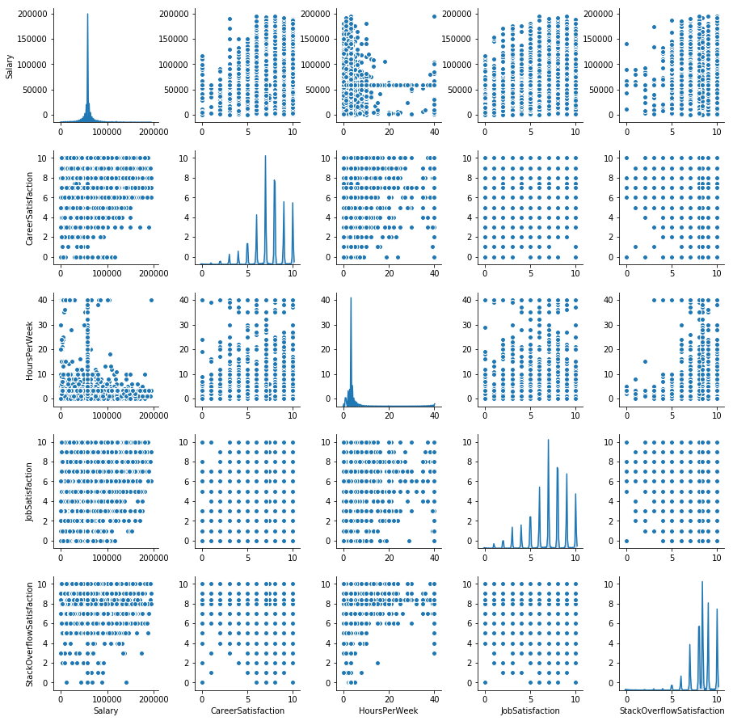

```python
sns.pairplot(fill_df, diag_kind="kde", diag_kws=dict(shade=True, bw=.05, vertical=False) )
```

### 5. Data Evaluation

Base on the available data seeing above, I figured out answer of following questions.

I. What are the most wanted programming language and framework?  
II. What are the factors that affect career satisfaction?  
III. What are the factors that affect job satisfaction?

**I. What are the most wanted programming language and framework?**  
We could figure out the languages that respondents have done done extensive development work in over the past year, and which they want to work in over the next year. According to the survey result, most popular languages are Java, JavaScript, Python, SQL and C#. 18% of respondents preferred Java, and 15% of respondents wanted JavaScript. Python was also popular among respondents, and 12% of respondents chose this language.

We could figure out the libraries, frameworks and tools that respondents have done done extensive development work in over the past year, and which they want to work in over the next year. According to the survey result, most popular frameworks are Node.js, AngularJS, React, Net Core and Xamarin. 22% of respondents preferred Node.js, and 18% of respondents wanted AngularJS. React was also popular among respondents, and 17% of respondents chose this framework.

**II. What are the factors that affect career satisfaction?**  
According to the survey result, employees who couldn't be employed although they had looked for job had the lowest career satisfaction. Retired employees had the highest career satisfaction. Full time employees had similar career satisfaction as employees who are independent contractor, freelancer , self-employed. Also, employees who never worked from home had the lowest career satisfaction.

According to the survey result, respondents who are employees of startup had the highest career satisfaction. However, respondents who are employees of state-owned company had the lowest career satisfaction. Employees who used to program as a hobby and contribute to open source projects had the highest career satisfaction. However, employees who don't program as a hobby had the lowest career satisfaction.

**III. What are the factors that affect job satisfaction?**  
According to the survey result, there is a strong connection between job satisfaction and career satisfaction. That is, if there are factors that affect career satisfaction, job satisfaction can be influenced by these factors. Also, salary and stack overflow satisfaction have an effect on job satisfaction. Employees who receive lots of salary and have high stack overflow satisfaction may have high job satisfaction.